# Poisson Regression

[output not shown]

[output cut: 10 more lines]

[output not shown]

[output not shown]

[output not shown]

[output not shown]

Examining the fit:

```r
precis(bayes_PoissonRegNoLink)
```

|  | mean | sd | 5.5% | 94.5% | n_eff | Rhat4 |
| --- | --- | --- | --- | --- | --- | --- |
| b0 | 1.11 | 0.11 | 0.94 | 1.3 | 105 | 1 |
| b1 | 0.20 | 0.00 | 0.19 | 0.2 | 189 | 1 |

Writing our second ULAM function. This function uses the yL data so it is trying to recapture the parameters using data generated with the Link function.

```r
bayes_PoissonRegLink <- ulam(
alist(
yL ~ dpois( lambda = myLambda ) ,
log(myLambda) <- b0 + b1 * x ,
b0 ~ dnorm( 0 , 5 ) ,
b1 ~ dnorm( 0 , 5 )

) , data = myData, chains = 4,iter=10000, log_lik = TRUE)
```

[output not shown]

[output not shown]

[output not shown]

[output not shown]

[output not shown]

```
1 warning generated.
```

[output not shown]

[output cut: 371 more lines]

[output not shown]

```r
precis(bayes_PoissonRegLink)
```

|  | mean | sd | 5.5% | 94.5% | n_eff | Rhat4 |
| --- | --- | --- | --- | --- | --- | --- |
| b0 | 1.00 | 0.03 | 0.96 | 1.05 | 3526 | 1 |
| b1 | 0.02 | 0.00 | 0.02 | 0.02 | 3867 | 1 |

We can take draws from the posterior distribution using the extract.samples function.

```r
mySamples<-extract.samples(bayes_PoissonRegLink,n=1000)
mySamples
```

[output not shown]

[output cut: 117 more lines]

Now lets make some posterior predictions. We have to supply data for where we want the predictions.This is specified in the ‘data=’ code below.

The link function returns the draws for the posterior Lambda at each level of x, whereas the sim returns draws of actual data Y or counts from each level of x.

```r
myPredictLambda<-link(fit=bayes_PoissonRegLink,data=list(x=c(10,20,30)),
                   n=1000)
head(myPredictLambda)
```

```
         [,1]     [,2]     [,3]
[1,] 3.291147 4.024847 4.922113
[2,] 3.234573 3.972458 4.878672
[3,] 3.401274 4.142254 5.044659
[4,] 3.292486 4.017095 4.901175
[5,] 3.292230 4.017175 4.901754
[6,] 3.451763 4.201367 5.113760
```

```r
myPredictObs<-sim(fit=bayes_PoissonRegLink,data=list(x=c(10,20,30)),
                   n=1000)
head(myPredictObs)
```

```
     [,1] [,2] [,3]
[1,]    3    5    8
[2,]    4    7    4
[3,]    3    6    3
[4,]    2    4    1
[5,]    4    4    4
[6,]    2    2    5
```

Finally, making some traceplots to examine the mcmc samples. You can either use the functions built into rethinking or try using some of the other R libraries for examining mcmc fits. This may require some conversions of the ulam output to be compatible with the other libraries.

```r
traceplot_ulam(bayes_PoissonRegLink)
```

converting samples for use with coda library.

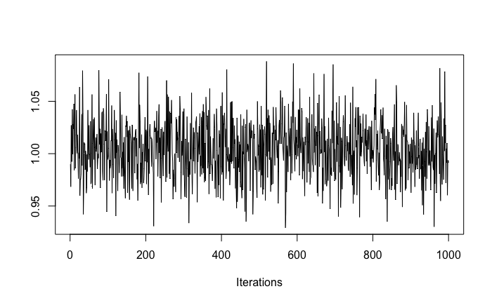

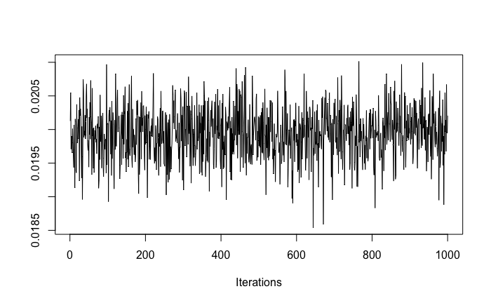

```r
library(coda)
mySamples<-extract.samples(bayes_PoissonRegLink,n=1000)
mySamples<-as.mcmc(cbind(mySamples$b0,mySamples$b1))
traceplot(mySamples)
```

```r
NA
NA
NA
```

Here is another MCMC library that could be useful: tidybayes. I don’t demonstrate it here but want folks to be aware of it. For tidybayes, you need to add a rethinking extension. See this link: https://mjskay.github.io/tidybayes.rethinking/

MCMCvis is another library that could probably be made to work with rethinking.

Scratch code below………this is code that I often find useful but is not central to what is done above

Here is some code to detach all libraries…

```r
invisible(lapply(paste0('package:', names(sessionInfo()$otherPkgs)), detach, character.only=TRUE, unload=TRUE))
```

```r
library(pryr)
```

```r
S4toList <- function(obj) {
   sn <- slotNames(obj)
   structure(lapply(sn, slot, object = obj), names = sn)
}
S4toList(bayes_PoissonRegLink)
```

[output not shown]